# RS_en

- 1.Data Cleaning & Exploratory Data Analysis (EDA)
  - 1.1 Data Format
  - 1.2 Dataset Scale
  - 1.3 Data Distribution
  - 1.4 Top-Ranked Anime by Rating
  - 1.5 Relationship Between Number of Ratings and Rating Score
  - 1.6 Web Scraping Anime Data
- 2.Recall Layer
  - 2.1 Constructing Item Sequences with DeepWalk
  - 2.2 Training Item and User Embeddings Using Item2Vec
  - 2.3 Storing Trained Embeddings in Redis
  - 2.4 Approximate Nearest Neighbor Search with LSH
- 3.Ranking Layer
  - 3.1 User Feature Construction
  - 3.2 Feature Engineering: Scaling Numerical Features
  - 3.3 Feature Engineering: One-Hot Encoding of Categorical Features
  - 3.4 Processing Online User and Item Features
- 4.MLP Neural Network Training
  - 4.1 Model Training with TensorFlow
  - 4.2 Hyperparameter Tuning
- 5.Backend Deployment for Recall, Ranking, and Client-Facing API

# 1.Data Cleaning & Exploratory Data Analysis (EDA)

### 1.1 Data Format

```python
import pandas as pd
import matplotlib.pyplot as plt
import seaborn
import csv
```

```python
anime_df=pd.read_csv("E:/Recomendation_sys_project/archive/parsed_anime.csv",index_col='anime_id')
rating_df=pd.read_csv("E:/Recomendation_sys_project/archive/rating.csv")
```

```python
anime_df.dtypes
```

```
name               object
genre              object
type               object
episodes           object
rating            float64
members             int64
japanese_title     object
aired              object
image_url          object
aired_from          int64
aired_to            int64
dtype: object
```

```python
rating_df.dtypes
```

```
user_id     int64
anime_id    int64
rating      int64
dtype: object
```

```python
#检查空值
anime_df[anime_df['episodes'].isna()==True]
```

|  | name | genre | type | episodes | rating | members | japanese_title | aired | image_url | aired_from | aired_to |
| --- | --- | --- | --- | --- | --- | --- | --- | --- | --- | --- | --- |
| anime_id |  |  |  |  |  |  |  |  |  |  |  |

```python
#检查出那些非数值类的str，并用NaN填补，然后dropna就可以
anime_df['episodes']=pd.to_numeric(anime_df['episodes'],errors='coerce')
#之后来写查看那些非数值类的episodes的代码，留一个坑！
```

```python
anime_df[anime_df['episodes'].isna()==True].shape[0]
```

```
340
```

```python
anime_df[anime_df['rating'].isna()==True].shape[0]
```

```
230
```

```python
anime_df[anime_df['genre'].isna()==True].shape[0]
```

```
62
```

```python
len(anime_df[anime_df['type'].isna()==True])
```

```
25
```

```python
#删空值，只要某一行有就删除
anime_df=anime_df.dropna(subset=['episodes','rating','genre','type'])
anime_df['episodes']=anime_df['episodes'].astype(int)
anime_df['rating']=anime_df['rating'].astype(int)
anime_df.dtypes
```

```
name              object
genre             object
type              object
episodes           int32
rating             int32
members            int64
japanese_title    object
aired             object
image_url         object
aired_from         int64
aired_to           int64
dtype: object
```

```python
anime_df['genre'].unique()
```

```python
#有43中genres
genre_list=[gen.split(',') for gen in anime_df['genre']]
genre=set([g.strip() for gen in genre_list for g in gen])
len(genre)
```

[output not shown]

```python
print(anime_df['type'].unique())
print(anime_df['type'].nunique())
```

```python
print(rating_df['rating'].unique())
print(rating_df['rating'].nunique())
```

### 1.2 Dataset Scale

This dataset contains over 70,000 users and more than 10,000 anime titles, which represents a suitable scale for modeling. However, the nearly 8 million user ratings introduce additional challenges for subsequent model selection and training.

```python
rating_df.shape[0]
```

```
7813737
```

```python
unique_anime_count=rating_df['anime_id'].nunique()
unique_user_count=rating_df['user_id'].nunique()
```

```python
unique_anime_count
```

```
11200
```

```python
unique_user_count
```

```
73515
```

### 1.3 Data Distribution

#### Exploring the Distribution of Continuous Variables for Feature Scaling

**Summary** For anime-level feature representation, the selected features include genre, type, episodes, rating, and members. For user-level feature representation, features include the average rating given by the user, preferred genres, preferred types, and the average number of episodes of anime the user has rated.

```
count    11830.000000
mean        12.486729
std         47.097131
min          1.000000
25%          1.000000
50%          2.000000
75%         12.000000
max       1818.000000
Name: episodes, dtype: float64
```

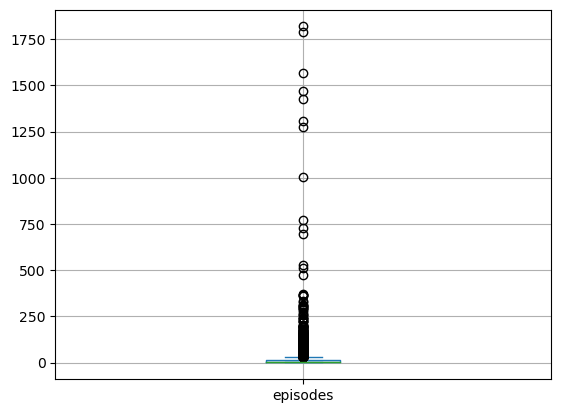

```python
anime_df['episodes'].plot.box(grid=True)
anime_df['episodes'].describe()
```

```
count    11830.000000
mean         6.006932
std          1.054658
min          1.000000
25%          5.000000
50%          6.000000
75%          7.000000
max         10.000000
Name: rating, dtype: float64
```

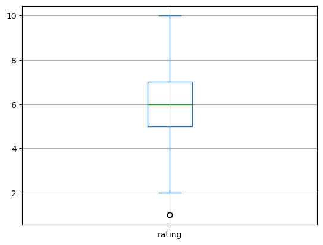

```python
anime_df['rating'].plot(kind='box',grid=True)
anime_df['rating'].describe()
```

```
count    1.183000e+04
mean     1.851100e+04
std      5.537144e+04
min      1.200000e+01
25%      2.322500e+02
50%      1.589500e+03
75%      9.832000e+03
max      1.013917e+06
Name: members, dtype: float64
```

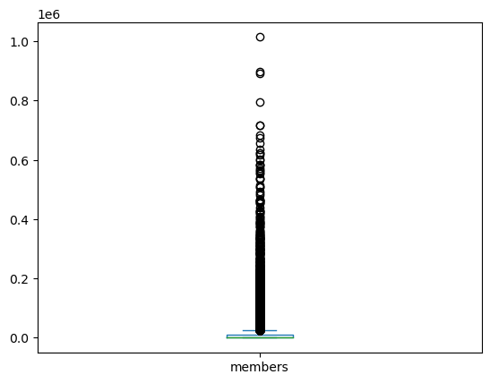

```python
anime_df['members'].plot(kind='box')
anime_df['members'].describe()
```

```python
uniq_ratings=rating_df['rating'].nunique()
uniq_ratings
```

```
11
```

```python
rating_df['rating'].unique()
```

```
array([-1, 10,  8,  6,  9,  7,  3,  5,  4,  1,  2], dtype=int64)
```

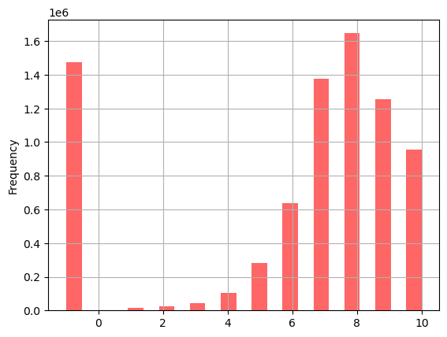

```python
rating_df['rating'].plot.hist(bins=2*uniq_ratings+1,alpha=0.6,color='red',grid=True)
```

```python
valid_rating=rating_df[rating_df['rating']>-1]
```

```python
valid_rating.groupby('anime_id').count().describe()
```

|  | user_id | rating |
| --- | --- | --- |
| count | 9927.000000 | 9927.000000 |
| mean | 638.384305 | 638.384305 |
| std | 1795.865541 | 1795.865541 |
| min | 1.000000 | 1.000000 |
| 25% | 9.000000 | 9.000000 |
| 50% | 57.000000 | 57.000000 |
| 75% | 395.000000 | 395.000000 |
| max | 34226.000000 | 34226.000000 |

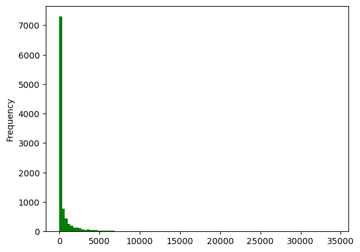

```python
valid_rating.groupby('anime_id')['rating'].count().plot.hist(bins=100,grid=False,color='green')
```

#### Distribution of User Ratings

```python
valid_rating.groupby("user_id").count().describe()
```

|  | anime_id | rating |
| --- | --- | --- |
| count | 69600.000000 | 69600.000000 |
| mean | 91.052313 | 91.052313 |
| std | 135.764253 | 135.764253 |
| min | 1.000000 | 1.000000 |
| 25% | 13.000000 | 13.000000 |
| 50% | 45.000000 | 45.000000 |
| 75% | 114.000000 | 114.000000 |
| max | 3747.000000 | 3747.000000 |

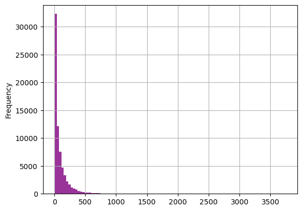

```python
valid_rating.groupby("user_id")["rating"].count().plot.hist(bins=100,grid=True,alpha=0.8,color='purple')
```

#### Distribution of animation types

```python
genres={}
```

```python
for (index, row) in anime_df.iterrows():
        genre_anime=[g.strip() for g in row['genre']]
        for genre in genre_anime:
            if genre not in genres:
                genres[genre]=0
            genres[genre]+=1
print(genres)
```

```
{'D': 2497, 'r': 12186, 'a': 18507, 'm': 9143, ',': 23371, '': 26550, 'R': 1436, 'o': 19086, 'n': 15835, 'c': 14120, 'e': 22100, 'S': 9760, 'h': 5402, 'l': 5615, 'u': 8114, 'p': 2441, 't': 12317, 'A': 5415, 'i': 18441, 'd': 8723, 'v': 2293, 'F': 4247, 's': 7291, 'y': 8704, 'M': 3656, 'g': 968, 'C': …
```

[figure not shown]

```python
fig=plt.figure(figsize=(20,10))
ax=fig.add_axes([0,0,1,1])
tuples=sorted(genres.items(),key=lambda x:x[1])
labels=[t[0] for t in tuples]
values=[t[1] for t in tuples]
ax.bar(labels,values)
plt.xticks(rotation=50,fontsize=17)
plt.show()
```

```python
type_anime={}
```

```python
for (index, row) in anime_df.iterrows():
    if row['type'] not in type_anime:
        type_anime[row['type']]=0
    type_anime[row['type']]+=1
print(type_anime)
```

```
{'Movie': 2258, 'TV': 3568, 'OVA': 3246, 'Special': 1665, 'Music': 487, 'ONA': 606}
```

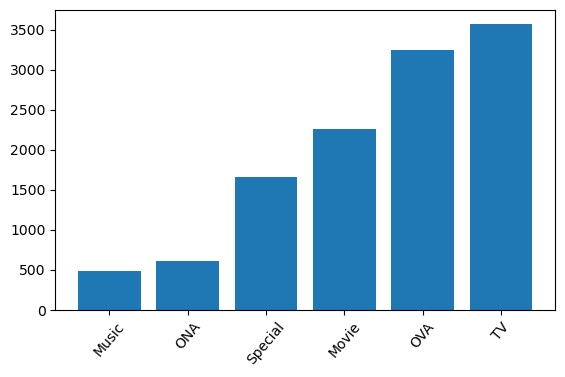

```python
fig=plt.figure(figsize=(5,3))
ax=fig.add_axes([0,0,1,1])
tuples=sorted(type_anime.items(),key=lambda x:x[1])
labels=[t[0] for t in tuples]
values=[t[1] for t in tuples]
ax.bar(labels,values)
plt.xticks(rotation=50,fontsize=10)
plt.show()
```

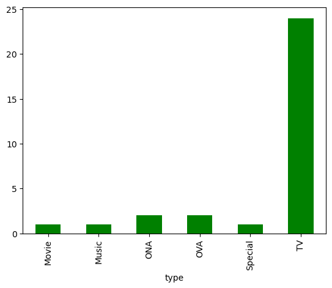

```python
anime_df.groupby('type')['episodes'].median().plot(kind='bar', color='green')
```

### 1.4 Top-Ranked Anime by Rating

```python
#anime_id是index，所以不能当做列来取
top20_animes=anime_df.sort_values(by='rating',ascending=False)[['name','type','rating']].iloc[:20]
top20_animes
```

| anime_id | name | type | rating |
| --- | --- | --- | --- |
| 33662 | Taka no Tsume 8: Yoshida-kun no X-Files | Movie | 10 |
| 918 | Gintama | TV | 9 |
| 23005 | Mogura no Motoro | Movie | 9 |
| 26145 | Okaachan Gomen ne | Movie | 9 |
| 33980 | Mirai ni Mukete: Bousai wo Kangaeru | Movie | 9 |
| 26259 | Mienu Me ni Kanjita Kumotoriyama no Asahi | OVA | 9 |
| 34191 | Santa-san wa Dai Isogashi | OVA | 9 |
| 32627 | Shaka no Shougai | Movie | 9 |
| 32796 | Shenmi Shijie Lixian Ji | Movie | 9 |
| 33607 | Kahei no Umi | Movie | 9 |
| 26313 | Yakusoku: Africa Mizu to Midori | OVA | 9 |
| 5114 | Fullmetal Alchemist: Brotherhood | TV | 9 |
| 32281 | Kimi no Na wa. | Movie | 9 |
| 15335 | Gintama Movie: Kanketsu-hen - Yorozuya yo Eien... | Movie | 9 |
| 28851 | Koe no Katachi | Movie | 9 |
| 4181 | Clannad: After Story | TV | 9 |
| 28977 | Gintama° | TV | 9 |
| 9253 | Steins;Gate | TV | 9 |
| 9969 | Gintama&#039; | TV | 9 |
| 11061 | Hunter x Hunter (2011) | TV | 9 |

```python
top20_animes['type'].nunique()
```

```
3
```

```python
top20_animes.groupby('type')['rating'].count()#受欢迎程度按照每种类型的评价数量，评价数量越多的，越受欢迎
```

```
type
Movie    10
OVA       3
TV        7
Name: rating, dtype: int64
```

```python
top20_animes.groupby('type')['rating'].mean()#按照评分高低来衡量受欢迎程度。评分高的种类越瘦欢迎
```

```
type
Movie    9.1
OVA      9.0
TV       9.0
Name: rating, dtype: float64
```

```python
groupby_df=valid_rating.groupby('anime_id').agg({'rating':['count','mean']}).droplevel(axis=1,level=0)
```

```python
groupby_df=valid_rating.groupby('anime_id').agg({'rating':['count','mean']}).droplevel(axis=1,level=0)
```

### Web Scraping Anime Data

Developing a Spider Using the Scrapy Framework

```python
BASE_URL = 'https://myanimelist.net/anime'

class AnimeSpider(scrapy.Spider):
    name = "anime"

    def start_requests(self):
        with open('../../data/anime/anime.csv') as csv_file:
            reader = csv.DictReader(csv_file)
            anime_ids = [row["anime_id"] for row in reader]

            with open('output.csv') as output_file:
                output_reader = csv.DictReader(output_file)
                existing_anime_ids = [row['anime_id'] for row in output_reader]

                anime_ids = [id for id in anime_ids if id not in existing_anime_ids]

                for id in anime_ids:
                    yield scrapy.Request(url=f'{BASE_URL}/{id}', callback=self.parse, meta={'anime_id': id})
```

Webpage parsing

```python
def parse(self, response):
        anime_id = response.meta.get("anime_id")

        japanese_titles = response.xpath("//span[contains(text(), 'Japanese')]/../text()").getall()
        japanese_titles = [text.strip() for text in japanese_titles]
        japanese_titles = [text for text in japanese_titles if len(text) > 0][0]

        aired = response.xpath("//span[contains(text(), 'Aired')]/../text()").getall()
        aired = [text.strip() for text in aired]
        aired = [text for text in aired if len(text) > 0][0]

        image_url = response.xpath("//a[contains(@href, 'pics')]/img/@data-src").getall()[0]

        print(f"{japanese_titles}    {aired}")

        yield {
            'anime_id': anime_id,
            'japanese_title': japanese_titles,
            'aired': aired,
            'image_url': image_url
        }
```

# 2. Recall Layer

```python
import pyspark
from pyspark import SparkContext
from pyspark.sql import SparkSession
from pyspark.sql.functions import *
```

### 2.1 Constructing Item Sequences with DeepWalk

```python
spark= SparkSession\
       .builder\
       .appName("concre-reall")\
       .getOrCreate()
```

```python
rating_df=spark.read.csv('E:/Recomendation_sys_project/archive/rating.csv',header=True, inferSchema=True)
rating_df.printSchema()
rating_df=rating_df.where('rating>7.5')#评分大于7.5分的用户行为才表示推荐该电影
```

```
root
 |-- user_id: integer (nullable = true)
 |-- anime_id: integer (nullable = true)
 |-- rating: integer (nullable = true)
```

```python
watch_seq_df=rating_df.groupby('user_id').agg(collect_list(col('anime_id').cast('string')).alias("anime_ids"))
```

```python
watch_seq_df.show(10)
```

```
+-------+--------------------+
|user_id|           anime_ids|
+-------+--------------------+
|     31|[2581, 3784, 3785...|
|     34|[20, 30, 32, 147,...|
|     53|[101, 849, 1195, ...|
|     65|[687, 853, 1221, ...|
|     78|       [4224, 18153]|
|     85|[223, 356, 481, 5...|
|    108|[57, 61, 132, 147...|
|    137|         [121, 5114]|
|    148|[20, 81, 170, 263...|
|    155|[164, 199, 226, 3...|
+-------+--------------------+
only showing top 10 rows
```

In this dataset, only movies with ratings above 7 were included. Therefore, we assume that users’ rating behavior reflects their preference for and recommendation of these movies.

Constructing the adjacency matrix corresponds to building a graph embedding, where an edge between two nodes indicates that the two movies appear together in the rating list of at least one user. If two movies are rated (liked) by multiple users, this suggests an underlying relationship or similarity between them, allowing sequences to be formed.

These sequences are then used as input to a Word2Vec model to learn embeddings for each anime. The resulting embeddings capture the similarity between anime titles based on user behavior.

```python
watch_seq=watch_seq_df.collect()
```

```python
watch_seq[0]
```

```
Row(user_id=31, anime_ids=['2581', '3784', '3785', '5680', '6347', '6634', '7791', '8516', '8769', '8841', '9471', '9617', '9760', '9919', '9938', '10087', '10408', '10793', '10897', '11499', '11737', '11741', '11757', '11843', '12291', '13055', '13759', '14467', '14741', '14811', '14813', '15225', …
```

```python
watch_seq1=[ w['anime_ids'] for w in watch_seq ]#形成的是一个二维的list
```

```python
from collections import defaultdict
matrix=defaultdict(lambda:defaultdict(int))
matrix
```

```
defaultdict(<function __main__.<lambda>()>, {})
```

```python
for i in range(len(watch_seq1)):
    seq=watch_seq1[i]
    for j in range(len(seq)):
        for k in range(j+1,len(seq)):
            a=seq[j]
            b=seq[k]
            if a==b:
                continue
            matrix[a][b]+=1
            matrix[b][a]+=1
```

#### Transition Probability Matrix

In this dataset, only movies with ratings above 7 were included. Therefore, we assume that users’ rating behavior indicates that they like and recommend the movie.

```python
trans_probs=defaultdict(lambda: defaultdict(list))
```

```python
trans_probs=defaultdict(lambda: defaultdict(list))
def get_transfer_probs(vs):
    neighbours=list(vs.keys())
    total_weight=__builtin__.sum(vs.values())
    probs=[weight/total_weight for weight in vs.values()]
    return neighbours,probs
```

```python
for keys,indict in matrix.items():
    neigh,probs=get_transfer_probs(indict)
    trans_probs[keys]['neighbours']=neigh
    trans_probs[keys]["probs"]=probs
```

#### Random Selection of Entry Nodes

```python
entrence_items=list(trans_probs.keys())
```

```python
nodes_sum={i:__builtin__.sum(matrix[i].values()) for i in entrence_items}
```

```python
total_sum=__builtin__.sum(nodes_sum.values())
```

```python
entren_probs=[v/total_sum for k,v in nodes_sum.items()]
```

#### Deepwalk

```python
#1次deep walk的采样
rng= np.random.default_rng()
def one_walk(length,entrence_items,entrence_probs,transfer_probs):
    path=[]
    start_point=rng.choice(entrence_items,1,p=entrence_probs)[0]
    path.append(str(start_point))
    current_point=start_point
    for _ in range(length):
        next_point=rng.choice(transfer_probs[current_point]['neighbours'], 1, p=transfer_probs[current_point]['probs'])[0]
        path.append(str(next_point))
        current_point=next_point
    return path
```

```python
n=10000#在实际的工作中，这个值可以更大，采样500是不够用的
deepwalk_sample=[one_walk(19,entrence_items,entren_probs,trans_probs) for _ in range(n)]
```

```python
len(deepwalk_sample)
```

```
10000
```

### 2.2 Training Item and User Embeddings Using Item2Vec

```python
from pyspark.ml.feature import Word2Vec
```

```python
# 要用spark的word2vec，所以要将原始的list转化成spark的df
deepwalk_df=spark.createDataFrame([[ row] for row in deepwalk_sample],['anime_ids'])
```

```python
deepwalk_df.show(10)
```

```
+--------------------+
|           anime_ids|
+--------------------+
|[10357, 13601, 83...|
|[102, 437, 3470, ...|
|[10259, 553, 957,...|
|[889, 27831, 3196...|
|[71, 102, 343, 16...|
|[18893, 8630, 670...|
|[2251, 801, 138, ...|
|[5162, 3712, 1473...|
|[27833, 26349, 65...|
|[28285, 30390, 26...|
+--------------------+
only showing top 10 rows
```

```python
item2vec=Word2Vec(vectorSize=5,maxIter=2,windowSize=15)
item2vec.setInputCol('anime_ids')
item2vec.setOutputCol('anime_ids_vec')
```

```
Word2Vec_801903d1725b
```

```python
model=item2vec.fit(deepwalk_df)
```

```python
rec=model.findSynonyms('12293',10)
```

```python
#和12293 anime_id相似的动漫
rec.show()
```

```
+-----+------------------+
| word|        similarity|
+-----+------------------+
|28881|0.9943350553512573|
| 1018|0.9928957223892212|
|15359|0.9894927144050598|
|16904|  0.98778235912323|
|17074|0.9866194725036621|
| 2514|0.9834409952163696|
|23283|0.9806155562400818|
|10711|  0.97883141040802|
| 1256|0.9785686731338501|
| 9712|0.9766817092895508|
+-----+------------------+
```

```python
anime_df=pd.read_csv('E:/Recomendation_sys_project/archive/parsed_anime.csv',sep=',')
def show_anime_info(aid,anime_df):
    info=anime_df[anime_df['anime_id']==aid].iloc[0]
    print(aid,info['name'],info['genre'],info['type'],info['episodes'],info['japanese_title'])
```

```python
show_anime_info(12293,anime_df)
```

```
12293 Campione!: Matsurowanu Kamigami to Kamigoroshi no Maou Comedy, Ecchi, Fantasy, Harem, Magic, Romance TV 13 カンピオーネ！ ～まつろわぬ神々と神殺しの魔王～
```

```python
for row in rec.collect():
    show_anime_info(int(row['word']),anime_df)
```

```
28881 New Initial D Movie: Legend 2 - Tousou Cars, Seinen, Sports Movie 1 新劇場版　頭文字［イニシャル］D Legend2 -闘走-
1018 Majutsushi Orphen: Revenge Adventure, Comedy, Fantasy, Magic, Shounen TV 23 魔術士オーフェンRevenge
15359 Kyousou Giga (2012) Action, Fantasy, Supernatural ONA 5 京騒戯画
16904 K: Missing Kings Action, Super Power, Supernatural Movie 1 K MISSING KINGS
17074 Monogatari Series: Second Season Comedy, Mystery, Romance, Supernatural, Vampire TV 26 〈物語〉シリーズ セカンドシーズン
2514 Detective Conan OVA 04: Conan and Kid and Crystal Mother Adventure, Mystery, Police, Shounen OVA 1 名探偵コナン: コナンとキッドとクリスタルマザー
23283 Zankyou no Terror Psychological, Thriller TV 11 残響のテロル
10711 Plastic Neesan Comedy, School ONA 12 ＋チック姉さん
1256 Saint Seiya: Jashin Eris Adventure, Sci-Fi, Shounen Movie 1 聖闘士星矢 邪神エリス
9712 Maria†Holic Alive Comedy, Parody, School, Shoujo Ai TV 12 まりあ†ほりっく あらいぶ
```

#### user Embedding

To compute user embeddings, it is not necessary to reconstruct user sequences. A commonly used industry approach is to derive user embeddings from the embeddings of anime that the user likes. Specifically, a user’s embedding is constructed by taking the average of the embeddings of the anime they prefer.

This method has a solid mathematical foundation that can be further explored, and it is both practical and highly effective in real-world applications.

```python
anime_embedding=model.getVectors().collect()
```

```python
anime_embedding_dict={}
for row in anime_embedding:
        anime_embedding_dict[row['word']]=row['vector'].toArray()
```

```python
@udf(returnType='array<float>')
def get_anime_embedding(col):
    user_anime_embeddings=[anime_embedding_dict[aid] if aid in anime_embedding_dict else [] for aid in col]
    #过滤掉空的list
    #__builtin__.filter(function, iterable) 会检查里面一个一个的元素，前面的function返回true就留在list里，不满足就被删除掉
    #另外的一个写法user_anime_embeddings=[e for e in user_anime_embeddings if len(e)>0]
    user_anime_embeddings=list(__builtin__.filter(lambda x:(len(x)>0),user_anime_embeddings))

    if not user_anime_embeddings:
        return []
    user_embedding=np.mean(user_anime_embeddings,axis=0)
    return user_embedding.tolist()
```

```python
user_emd_df=watch_seq_df.withColumn('user_embedding',get_anime_embedding(col('anime_ids')))
```

```python
user_emd_df.show()
```

```
+-------+--------------------+--------------------+
|user_id|           anime_ids|      user_embedding|
+-------+--------------------+--------------------+
|     31|[2581, 3784, 3785...|[-0.16534768, -0....|
|     34|[20, 30, 32, 147,...|[-0.21643454, -0....|
|     53|[101, 849, 1195, ...|[-0.16089639, -0....|
|     65|[687, 853, 1221, ...|[-0.15135884, -0....|
|     78|       [4224, 18153]|[-0.08032584, -0....|
|     85|[223, 356, 481, 5...|[-0.18453135, -0....|
|    108|[57, 61, 132, 147...|[-0.17900786, -0....|
|    137|         [121, 5114]|[-0.21894813, -0....|
|    148|[20, 81, 170, 263...|[-0.19074963, -0....|
|    155|[164, 199, 226, 3...|[-0.19674842, -0....|
|    193|            [1, 205]|[-0.18421005, -0....|
|    211|[199, 877, 1535, ...|[-0.19143154, -0....|
|    243|[223, 269, 853, 1...|[-0.1861835, -0.0...|
|    251|[813, 2001, 9756,...|[-0.13488548, -0....|
|    255|[199, 269, 431, 2...|[-0.22314133, -0....|
|    296|[1, 6, 15, 17, 20...|[-0.18772782, -0....|
|    321|[121, 227, 889, 1...|[-0.19455597, -0....|
|    322|[20, 226, 356, 12...|[-0.2059239, -0.0...|
|    362|        [3457, 5682]|[-0.09943397, -0....|
|    368|[20, 246, 1195, 1...|[-0.17885077, -0....|
+-------+--------------------+--------------------+
only showing top 20 rows
```

### 2.3 Storing Trained Embeddings in Redis

In most cases, embeddings are stored using a key–value format. Since Redis can only store data as strings, the embedding vectors are converted into string representations before being stored.

```python
from redis import Redis
```

```python
redis=Redis()
```

As Redis only supports string-based storage, embedding vectors are serialized into strings before being stored in a key–value format.

```python
def vec2string(emb):
    return ':'.join(str(i) for i in emb)

def save_to_redis(df):
    user_emd_row=df.collect()
    emb_dict={}
    emb_dict={row.user_id: vec2string(row.user_embedding) for row in user_emd_row}
    redis.hset('recall-use-embedding',mapping=emb_dict)
```

```python
#'name:j:nn:d'.split(':')-->['name', 'j', 'nn', 'd'] spliT之后存成一个list
def str2vec(emb):
    return [float(i)for i in emb.split(':')]
```

```python
def read_user_emd():
    re=redis.hgetall('recall-use-embedding')
    return ({key.decode():  str2vec(value) for key,value in re.items()})
```

### 2.4 Approximate Nearest Neighbor Search with LSH

```python
import faiss
```

```python
emb_item={r.word: r.vector.toArray() for r in anime_embedding}
emb_item=list(__builtin__.filter(lambda x: len(x[1])>0,emb_item.items()))
```

```python
emb_item_key=[i[0] for i in emb_item]
```

```python
emb_item_vec=[i[1] for i in emb_item]
```

```python
index=faiss.IndexLSH(len(emb_item_vec[0]),256)
```

```python
index.add(np.asarray(emb_item_vec,dtype=np.float32))#一次性对所有Embedding训练，之后直接取用，不用每次都训练。
```

```python
D,I =index.search(np.asarray([emb_item_vec[99]],dtype=np.float32),10)
```

```python
print(D)
print(I)
```

```
[[ 0. 11. 11. 12. 12. 15. 15. 15. 15. 15.]]
[[  99  528 2830 1297 1793  566 2363 3016 3052 3423]]
```

# 3.Ranking Layer

### 3.1 User Feature Construction

```python
from pyspark.sql.types import IntegerType
anime_df=spark.read.csv('E:/Recomendation_sys_project/archive/parsed_anime.csv',header=True, inferSchema=True)
#
anime_df=anime_df\
         .withColumnRenamed("rating",'all_rating')\
         .withColumn('aired_from',col('aired_from').cast('int'))\
         .filter( col('genre').isNotNull()&
                  col('all_rating').isNotNull()&
                  col('aired_from').isNotNull()&
                  col("aired_to").isNotNull()
                )\
         .withColumn('episodes',col('episodes').cast('int'))
```

```python
anime_df.printSchema()
```

```
root
 |-- anime_id: integer (nullable = true)
 |-- name: string (nullable = true)
 |-- genre: string (nullable = true)
 |-- type: string (nullable = true)
 |-- episodes: integer (nullable = true)
 |-- all_rating: double (nullable = true)
 |-- members: integer (nullable = true)
 |-- japanese_title: string (nullable = true)
 |-- aired: string (nullable = true)
 |-- image_url: string (nullable = true)
 |-- aired_from: integer (nullable = true)
 |-- aired_to: integer (nullable = true)
```

```python
#rating_df的ratinng列没有空值
rating_df_rank=spark.read.csv('E:/Recomendation_sys_project/archive/rating.csv',header=True, inferSchema=True)
rating_df_rank=rating_df.where('rating>0')#评分大于7.5分的用户行为才表示推荐该电影
rating_df_rank.printSchema()
```

```
root
 |-- user_id: integer (nullable = true)
 |-- anime_id: integer (nullable = true)
 |-- rating: integer (nullable = true)
```

```python
like_threshold=7.5
merged_df=rating_df_rank.join(
          anime_df.select('anime_id','name','genre','type','episodes','all_rating','members','aired_from','aired_to'),
          on='anime_id',how='left'

).withColumn(
    'label',
    when(col('rating')>like_threshold,1).otherwise(0)

    ).filter(col('all_rating').isNotNull()|col('genre').isNotNull()| col('members').isNotNull())
```

```python
merged_df.count()
```

```
3855820
```

### 3.2 Feature Engineering: Scaling Numerical Features

#### numberic features: Standardization

```python
from pyspark.ml.feature import MinMaxScaler,VectorAssembler,StandardScaler
from pyspark.ml import Pipeline
from pyspark.sql import functions as F
import pyspark.sql.types as types
```

```python
@udf(types.FloatType())
def extract_float(s):
    NUMBER_PRECISION=2
    r=__builtin__.round(s[0],NUMBER_PRECISION)
    return float(r)
```

```python
class numbericScaler():
    def __init__(self, cols):
        self.cols=cols
        self.pipelines=self.__numeric_col(cols)

    def __numeric_col(self,cols):
        pipelines=[self.__numeric_single_col(col) for col in self.cols]
        Pipeline(stages=pipelines)
        return Pipeline(stages=pipelines)


    def __numeric_single_col(self, col):
        vec=VectorAssembler(inputCols=[col], outputCol=f'{col}_vec',handleInvalid='keep')
        scaler=StandardScaler(inputCol=f'{col}_vec', outputCol=f'{col}_Standardization',withMean=True,withStd=True)
        pipeline=Pipeline(stages=[vec,scaler])
        return pipeline

    def fit(self,df):
        self.model=self.pipelines.fit(df)#self.model是一个实例化变量，可以被在numericScaler类的其他的方法中使用

    def transform(self,df):
        result=self.model.transform(df)
        #drop all intermedia cols and covert output to float
        for col in self.cols:
            result=result\
               .drop(f'{col}_vec')\
               .withColumn(f'{col}_Standardization',extract_float(F.col(f'{col}_Standardization')))
        return result
```

### 3.3 Feature Engineering: One-Hot Encoding of Categorical Features

#### categorical data - multi hot

```python
from pyspark.ml.feature import StringIndexer
from pyspark.ml.linalg import SparseVector
```

```python
def encode_genres_col(index_mapping_broadcasted):
    @udf(returnType='array<int>')
    def encode_genres_col(colvalue,max_genre_index):
        if  colvalue is None:
            colvalue=[]
        genre_index=[index_mapping_broadcasted.value.get(i) for i in colvalue]
        genre_index=list(set(genre_index))

        fill=np.ones(len(genre_index),dtype=np.int32)
        sorted_index=np.sort(genre_index)
        multi_hot=SparseVector(max_genre_index+1,sorted_index,fill)
        return multi_hot.toArray().astype(np.int32).tolist()

    return encode_genres_col
```

```python
class CategoricalEncoder:
    def __init__(self,colname):
        self.colname=colname

    def fit(self,df):

        explode_df=df\
                   .withColumn(f'{self.colname}_item',explode(col(self.colname)))

        col_string=StringIndexer(inputCol=f'{self.colname}_item',outputCol=f'{self.colname}_index')
        model=col_string.fit(explode_df)
        labels_df=spark.createDataFrame(
                  [{f'{self.colname}_item': g} for g in model.labels]
              )
        mapping_df=model.transform(labels_df).collect()
        mapping_dict={row[f'{self.colname}_item'] : int(row[f'{self.colname}_index']) for row in mapping_df}
        self.max_index=__builtin__.max(mapping_dict.values())
        broadcast=spark.sparkContext.broadcast(mapping_dict)
        self.encode_fn=encode_genres_col(broadcast)

    def transform(self,df):
            result=df.withColumn(f'{self.colname}_multihot',
                           self.encode_fn(col(self.colname),lit(self.max_index)))

            return result
```

#### Build training dataset for DNN

```python
from pyspark.sql import Window
from collections import Counter
```

```python
windowSpec=Window\
       .partitionBy('user_id')\
       .orderBy('aired_from')\
       .rowsBetween(-100,-1)
```

```python
likeAnimeCol=lambda colname: when(col('label')==1,col(colname)).otherwise(None)


@udf(returnType='array<string>')
def genre_to_list(gen_str):
    if gen_str is None:
        return []

    gens=gen_str.split(',')
    return [g.strip() for g in gens]

@udf(returnType='array<string>')
def type_to_list(type_str):
    if type_str is None:
        return []
    return [type_str.strip()]


#chose first 5 like genre

@udf(returnType='array<string>')
def most_liked_genre(collect_str):
    #collect_str is list like ['action,drama,sci-fi','drama,adventure']
    genre=[i.split(',') for  i in collect_str]
    genre_list=[ge.strip() for i in genre for ge in i]
    genre_dict=dict(Counter(genre_list))
    genre_list_sorted=sorted(genre_dict.items(),key=lambda x:x[1],reverse=True)
    #select first 5 genre as users' most like
    most_like_genres=[key for key,value in genre_list_sorted[:5]]
    return most_like_genres

@udf(returnType='array<string>')
def most_liked_type(collect_type_list):
    #['move','music']
    collect_type=[c.strip() for c in collect_type_list]
    type_dict=dict(Counter(collect_type))
    #[('movie',5),('music',3)]
    sorted_type_list=sorted(type_dict.items(),key=lambda x: x[1],reverse=True)#x[1]就是以值来排序,拍完序之后返回的是一个list，不是dict
    #sorted_type_dict[:2]这样索引的切分只能用于list，tuple，string,不能用于dict
    if len(sorted_type_list)==0:
        return None
    elif len(sorted_type_list)<2:
        return [k for k,v in sorted_type_list]

    most_liked_type=[k for k,v in sorted_type_list[:2]]
    return most_liked_type
```

```python
feat_df=merged_df\
         .withColumn('genres',genre_to_list(col('genre')))\
         .withColumn('types',type_to_list(col('type')))\
         .withColumn('user_rating_cnt',count(lit(1)).over(windowSpec))\
         .withColumn('user_rating_ave',mean(col('rating')).over(windowSpec))\
         .withColumn('user_rating_ave',F.round(col('user_rating_ave'),2))\
         .withColumn('user_rating_std',stddev(col('rating')).over(windowSpec))\
         .withColumn('user_rating_std',F.round(col('user_rating_std'),2))\
         .withColumn('user_aired_from_ave', mean(likeAnimeCol('aired_from')).over(windowSpec))\
         .withColumn('user_aired_from_ave',F.round(col('user_aired_from_ave'),0))\
         .withColumn('user_aired_to_ave',mean(likeAnimeCol('aired_to')).over(windowSpec))\
         .withColumn('user_aired_to_ave',F.round(col('user_aired_to_ave'),0))\
         .withColumn('user_liked_genres',most_liked_genre(collect_list(likeAnimeCol('genre')).over(windowSpec)))\
         .withColumn('user_liked_type',most_liked_type(collect_list(likeAnimeCol('type')).over(windowSpec)))\
         .withColumn('user_episodes_ave',mean(likeAnimeCol('episodes')).over(windowSpec))\
         .withColumn('user_episodes_ave',F.round(col('user_episodes_ave'),0))
```

```python
feat_df=feat_df\
.filter(col('user_rating_ave').isNotNull())\
.filter(col('user_rating_std')!=0.0)\
.filter(col('user_rating_std').isNotNull())\
.filter(col('user_aired_from_ave').isNotNull())\
.filter(col('user_aired_to_ave').isNotNull())\
.filter(col('user_episodes_ave').isNotNull())\
.filter(col('episodes').isNotNull())
```

```python
feat_df.count()
```

```
3617190
```

1.Trian item numeric

```python
item_numeric_cols=[
    'all_rating',
    'members',
    'aired_from',
    'aired_to',
    'episodes'
]
item_numeric_scaler=numbericScaler(item_numeric_cols)
```

```python
item_numeric_scaler.fit(feat_df)
```

2.Train user numeric

```python
user_numeric_cols=[
    'user_rating_ave',
    'user_rating_std',
    'user_aired_from_ave',
    'user_aired_to_ave',
    'user_episodes_ave'

]
user_numeric_scaler=numbericScaler(user_numeric_cols)
```

```python
user_numeric_scaler.fit(feat_df)
```

3.Train item categorical

```python
item_categorical_encoder_g=CategoricalEncoder('genres')
item_categorical_encoder_g.fit(feat_df)

item_categorical_encoder_t=CategoricalEncoder('types')
item_categorical_encoder_t.fit(feat_df)
```

4.Train user cattegorical

```python
user_categorical_encoder_g=CategoricalEncoder('user_liked_genres')
user_categorical_encoder_g.fit(feat_df)

user_categorical_encoder_t=CategoricalEncoder('user_liked_type')
user_categorical_encoder_t.fit(feat_df)
```

#### Transform

1.user & item numeric

```python
transformed_df=item_numeric_scaler.transform(feat_df)
transformed_df=user_numeric_scaler.transform(transformed_df)
```

2.user & item categorical

```python
transformed_df=item_categorical_encoder_g.transform(transformed_df)
transformed_df=item_categorical_encoder_t.transform(transformed_df)
transformed_df=user_categorical_encoder_g.transform(transformed_df)
transformed_df=user_categorical_encoder_t.transform(transformed_df)
```

```python
transformed_df.show(10,vertical=True)
```

```
-RECORD 0---------------------------------------------------
 anime_id                            | 6347
 user_id                             | 31
 rating                              | 9
 name                                | Baka to Test to S...
 genre                               | Comedy, Romance, ...
 type                                | TV
 episodes                            | 13
 all_rating                          | 7.83
 members                             | 301282
 aired_from                          | 1262793600
 aired_to                            | 1270051200
 label                               | 1
 genres                              | [Comedy, Romance,...
 types                               | [TV]
 user_rating_cnt                     | 3
 user_rating_ave                     | 8.67
 user_rating_std                     | 0.58
 user_aired_from_ave                 | 1.226304E9
 user_aired_to_ave                   | 1.2337632E9
 user_liked_genres                   | [Action, Mecha, S...
 user_liked_type                     | [TV, Movie]
 user_episodes_ave                   | 13.0
 all_rating_Standardization          | -0.05
 members_Standardization             | 0.43
 aired_from_Standardization          | 0.18
 aired_to_Standardization            | 0.15
 episodes_Standardization            | -0.19
 user_rating_ave_Standardization     | -0.39
 user_rating_std_Standardization     | -0.91
 user_aired_from_ave_Standardization | 0.65
 user_aired_to_ave_Standardization   | 0.61
 user_episodes_ave_Standardization   | -0.63
 genres_multihot                     | [1, 0, 1, 0, 0, 0...
 types_multihot                      | [1, 0, 0, 0, 0, 0]
 user_liked_genres_multihot          | [0, 1, 1, 0, 0, 0...
 user_liked_type_multihot            | [1, 1, 0, 0, 0, 0]
-RECORD 1---------------------------------------------------
 anime_id                            | 7791
 user_id                             | 31
```

[output cut: 316 more lines]

```
 all_rating_Standardization          | 0.2
 members_Standardization             | -0.15
 aired_from_Standardization          | 0.46
 aired_to_Standardization            | 0.44
 episodes_Standardization            | -0.19
 user_rating_ave_Standardization     | -0.83
 user_rating_std_Standardization     | -1.33
 user_aired_from_ave_Standardization | 0.88
 user_aired_to_ave_Standardization   | 0.85
 user_episodes_ave_Standardization   | -0.63
 genres_multihot                     | [1, 0, 1, 0, 0, 0...
 types_multihot                      | [1, 0, 0, 0, 0, 0]
 user_liked_genres_multihot          | [1, 1, 0, 0, 0, 0...
 user_liked_type_multihot            | [1, 1, 0, 0, 0, 0]
only showing top 10 rows
```

### 3.4 Processing Online User and Item Features

For user and item feature sets used in online services, it is not necessary to repeatedly process all historical anime information that users have interacted with. Instead, only the most up-to-date anime features are required.

From the moment the model is deployed, the data used for online inference only needs to reflect the latest feature values. For example, anime feature states from one day ago, one month ago, or one year ago are not relevant for online serving and do not need to be considered.

```python
anime_genre_df=anime_df\
       .withColumn('genres',genre_to_list('genre'))
```

anime numeric

```python
cc=item_numeric_scaler.transform(anime_genre_df)
```

anime categorical

```python
item_both_transformed_df=item_categorical_encoder.transform(cc)
item_both_transformed_df.count()
```

```python
item_both_transformed_df.show(10,vertical=True)
```

[output not shown]

The processed data should be stored in appropriate locations so that it can be reused by the entire system in subsequent stages. Data required for deep learning model training can be written to CSV files.

Since deep learning model training is performed offline and can be conducted in batch or mini-batch mode, it is not necessary to store these data in online, low-latency databases such as Redis. Instead, they can be stored in colder storage solutions, such as HDFS or local disk, which are more suitable for offline computation.

```python
w=Window.partitionBy('user_id')
```

```python
user_feat_df=feat_df\
            .withColumn('max_aired',max(col('aired_from')).over(w))\
            .where(col('max_aired')==col('aired_from'))\
            .drop('max_aired')
#alternative code
#w1=Window.partitionBy('user_id').orderBy(col('aired_from').desc()).
#feat_df\
      #.withColumn('row_index',row_number().over(w1))\ #在窗口排好序之后，给每一行一个index，取row index是1的都能保证取到最大值的那一行
      #.filter(col('row_index')==1)\
      #.drop('row_index')
```

```python
user_feat_df.select('user_id','anime_id','aired_from').show(5)
```

```python
user_numeric_transformed_df=user_numeric_scaler.transform(user_feat_df)
```

```python
user_both_transformed_df=user_categorical_encoder.transform(user_numeric_transformed_df)
user_both_transformed_df.count()
```

```python
user_both_transformed_df.show(10,vertical=True)
```

[output not shown]

#### Save user and item features to redis，available for online systems to access at any time.

```python
item_features=item_both_transformed_df.collect()
```

```python
item_features[1]
```

```python
user_features=user_both_transformed_df.collect()
```

```python
user_features[1]
```

# 4. MLP Neural Network Training

```python
import os
import pandas as pd
import tensorflow as tf
import tensorflow.keras as keras
import numpy as np
from pyspark.sql import SparkSession
```

```python
spark = SparkSession.builder.appName("ReadParquet").getOrCreate()
```

#### Define features

During model training, the data are loaded and processed using helper functions that extract the required numerical and categorical features. These features are then converted into NumPy arrays. Since TensorFlow supports NumPy arrays as input, the data cannot be provided as pandas DataFrames or Python lists.

```python
def get_item_numeric_features(df):
    numeric_features=[
        "all_rating_Standardization",
        "members_Standardization",
        "aired_from_Standardization",
        "aired_to_Standardization" ,
        "episodes_Standardization"
    ]
    return df[numeric_features].to_numpy()

def get_user_numeric_features(df):
    numeric_features=[
    'user_rating_ave_Standardization',
    'user_rating_std_Standardization',
    'user_aired_from_ave_Standardization',
    'user_aired_to_ave_Standardization',
    'user_episodes_ave_Standardization'
    ]
    return df[numeric_features].to_numpy()
```

```python
def get_multihot_features(df,feat_name):

    feat_df=df[[feat_name]]
    feat_vec=feat_df.to_numpy()
    feat_vec=np.apply_along_axis(lambda v: v[0],1,feat_vec)
    return feat_vec
```

```python
def get_label(df):
    label=df[['label']]
    return label
```

```python
def get_all_features(df):
    return(
        get_multihot_features(df,'genres_multihot'),
        get_multihot_features(df,'user_liked_genres_multihot'),
        get_item_numeric_features(df),
        get_user_numeric_features(df)
    )
```

#### Load data

```python
#root是文件的绝对路径，files是文件名称
def data_files():
    filename=[]
    for root,dirs, files in os.walk('E:\Recomendation_sys_project\DNN_training_data'):
        for f in files:
            if f.endswith('.parquet'):
                filename.append(os.path.join(root,f))
    return filename
```

```python
file_path=data_files()
```

```python
for file in file_path:
    #df=pd.read_parquet(file)
    df=spark.read.parquet(file)
```

```python
get_item_numeric_features(df)#将传入的numeric_features的四个数值特征构成一个4维的数值向量
```

[output not shown]

```python
train_df=transformed_df.sample(frac=0.8,random_state=666)
test_df=transformed_df.drop(train_df.index)
```

```python
train_x1,train_x2,train_x3,train_x4=get_all_features(train_df)
```

```python
len(train_x1)
```

```python
test_x1,test_x2,test_x3,test_x4=get_all_features(test_df)
```

```python
train_y=get_label(train_df)
test_y=get_label(test_df)
```

### 4.1 Model Training with TensorFlow

x1: item categorical features  
x2: user catergorical features  
x3: item numeric features  
x4: user numerica features

```python
def build_model(x1_shape,x2_shape,x3_shape,x4_shape):
    x1_input=keras.layers.Input(shape=(x1_shape,))
    x2_input=keras.layers.Input(shape=(x2_shape,))
    x3_input=keras.layers.Input(shape=(x3_shape,))
    x4_input=keras.layers.Input(shape=(x4_shape,))
    #end2end  embedding 降维
    compact_x1=keras.layers.Dense(10)(x1_input)
    compact_x2=keras.layers.Dense(10)(x2_input)

    #输入层
    merge=keras.layers.concatenate([compact_x1,compact_x2,x3_input,x4_input])
    #隐藏层
    #first hidden layer,128个神经元
    h1=keras.layers.Dense(128,activation='relu')(merge)
    h2=keras.layers.Dense(128,activation='relu')(h1)
    #输出层
    output=keras.layers.Dense(1,activation='sigmoid')(h2)

    model=keras.models.Model(inputs=[x1_input,x2_input,x3_input,x4_input],outputs=output)
    return model
```

```python
model3=build_model(43,43,5,5)
```

```python
model3.compile(
    loss='binary_crossentropy',
    optimizer='adam',
    metrics=['accuracy']
)
```

```python
model3.fit([train_x1,train_x2,train_x3,train_x4],train_y,batch_size=30,epochs=2,validation_split=0.2)
```

```python
model2=build_model(43,43,5,5)
```

[figure not shown]

```python
keras.utils.plot_model(model2,show_shapes=True)
```

```python
model2.compile(
    loss='binary_crossentropy',
    optimizer='adam',
    metrics=['accuracy']
)

#batch_size训练数据分批的批次，epochs训练几轮
model2.fit([train_x1,train_x2,train_x3,train_x4],train_y,batch_size=30,epochs=2,validation_split=0.2)
```

```
<keras.callbacks.History at 0x17b793a2520>
```

#### test model (first attempt)

```python
test_loss,test_accuracy=model.evaluate([test_x1,test_x2,test_x3,test_x4],test_y)
```

[output not shown]

### 4.2 Hyperparameter Tuning

```python
from tensorboard.plugins.hparams import api as hp
```

```python
HP_LAYERS=hp.HParam('layers',hp.IntInterval(2,3))
HP_LAYER_SIZE=hp.HParam('layer_size',hp.Discrete([64,128,256]))
HP_LEARN_RATE=hp.HParam('learning_rate',hp.Discrete([0.001,0.003,0.01]))
HParam=[
    HP_LAYERS,
    HP_LAYER_SIZE,
    HP_LEARN_RATE
]

METRICS=[
    hp.Metric('loss',group='train',display_name='loss_train'),
    hp.Metric('loss',group='validation',display_name='loss_val')
]
```

```python
def tuning_model(x1_shape,x2_shape,x3_shape,x4_shape,hparam):
    x1_input=keras.layers.Input(shape=(x1_shape,))
    x2_input=keras.layers.Input(shape=(x2_shape,))
    x3_input=keras.layers.Input(shape=(x3_shape,))
    x4_input=keras.layers.Input(shape=(x4_shape,))
    #end2end  embedding 降维
    compact_x1=keras.layers.Dense(10)(x1_input)
    compact_x2=keras.layers.Dense(10)(x2_input)

    #输入层
    merge=keras.layers.concatenate([compact_x1,compact_x2,x3_input,x4_input])
    h_pre=merge
    for _ in range(hparam[HP_LAYERS]):
        h=keras.layers.Dense(hparam[HP_LAYER_SIZE],activation='relu')(h_pre)
        h_pre=h

    #输出层
    output=keras.layers.Dense(1,activation='sigmoid')(h)

    model=keras.models.Model(inputs=[x1_input,x2_input,x3_input,x4_input],outputs=output)

    opt=keras.optimizers.Adam(learning_rate=hparam[HP_LEARN_RATE])
    model.compile(
    loss='binary_crossentropy',
    optimizer=opt,
    metrics=['accuracy']
        )
    #tf.config.run_functions_eagerly(True)
    tf.data.experimental.enable_debug_mode()
    return model
```

```python
#构建可能的超参数组合
#然后对每个模型传输这些超参数组合
def test_param(df):

    with tf.summary.create_file_writer('hparams').as_default():
         hp.hparams_config(hparams=HParam, metrics=METRICS)

    model_id=0
    for layers in range(HP_LAYERS.domain.min_value,HP_LAYERS.domain.max_value+1):
        for size in HP_LAYER_SIZE.domain.values:
            for rate in HP_LEARN_RATE.domain.values:
                #之前创建的HParam对象(HP_LAYERS)为键
                hparam_dict={
                    HP_LAYERS:layers,
                    HP_LAYER_SIZE:size,
                    HP_LEARN_RATE:rate
                }
                run_model(hparam_dict,model_id,df)
                model_id+=1


#给定某一个超参数组合，给定模型，并且训练模型
#给每个model一个ID
def run_model(hparams,model_id,df):

    model_t=tuning_model(43,43,4,4,hparams)
    print(f"\nmodel id: {model_id}")
    print({p.name: hparams[p] for p in hparams})
    #
    log_filename=f'{model_id}'
    for h in hparams:
        log_filename+=f"_{h.name}_{hparams[h]}"

    log_dir=os.path.join('hparams',log_filename)
    tensorboard_callback=tf.keras.callbacks.TensorBoard(
        log_dir=log_dir,
        update_freq=10,
        profile_batch=0
    )
    hparams_callback=hp.KerasCallback(log_dir,hparams)
    #读取文件
    #file_path=data_files()
    #for file in file_path:
         #df=pd.read_parquet(file)

    train_df=df
    train_x1,train_x2,train_x3,train_x4=get_all_features(train_df)
    train_y=get_label(train_df)
    model_t.fit(
         [train_x1,train_x2,train_x3,train_x4],
         train_y,
         batch_size=25,
         epochs=4,
         validation_split=0.2,
         callbacks=[tensorboard_callback,hparams_callback]
    )
```

```python
%rm -rf hparam
test_param(df)
```

```
model id: 0
{'layers': 2, 'layer_size': 64, 'learning_rate': 0.001}

model id: 1
{'layers': 2, 'layer_size': 64, 'learning_rate': 0.003}

model id: 2
{'layers': 2, 'layer_size': 64, 'learning_rate': 0.01}
```

```python
% load_ext tensorboard
%tensorboard --logdir hparams
```

#### Save Model

```python
model2.save('mlp_model')
```

```
INFO:tensorflow:Assets written to: mlp_model\assets
```

# 5. Backend Deployment for Recall, Ranking, and Client-Facing API

https://github.com/Alicege007/Recomendation_sys/tree/main/API_Service